# World Series Potential Matchup: A Head-To-Head Comparison of Nathan Eovaldi and Zack Wheeler and An Analysis of the Matchup between Nathan Eovaldi and Bryce Harper

```r
knitr::opts_chunk$set(echo = TRUE)
```

```r
library(ggplot2) # Load ggplot2
library(reshape) # Load tidyverse
```

For this analysis I will work with statcast data. There are a few pre-processing steps to go through, but I loaded in the modified data stored as `statcast_2023.rda`. This dataset contains all of the pitches from the 2023 MLB season.

```r
load("statcast_2023.rda") # Load data
```

```r
head(statcast)
```

|  | pitch_type | game_date | release_speed | release_pos_x | release_pos_z | player_name | batter | pitcher | events | description | spin_dir | spin_rate_deprecated | break_angle_deprecated | break_length_deprecated | zone | des | game_type | stand | p_throws | home_team | away_team | type | hit_location | bb_type | balls | strikes | game_year | pfx_x | pfx_z | … |
| --- | --- | --- | --- | --- | --- | --- | --- | --- | --- | --- | --- | --- | --- | --- | --- | --- | --- | --- | --- | --- | --- | --- | --- | --- | --- | --- | --- | --- | --- | --- |
| 1 | SL | 2023-07-09 | 85.5 | -1.10 | 4.89 | Díaz, Elias | 553869 | 657277 | strikeout | swinging_strike | NA | NA | NA | NA | 14 | Elias Diaz strikes out swinging. | R | R | R | SF | COL | S | 2 |  | 1 | 2 | 2023 | 1.24 | 0.08 | … |
| 2 | CH | 2023-07-09 | 90.6 | -1.12 | 4.97 | Díaz, Elias | 553869 | 657277 |  | foul | NA | NA | NA | NA | 9 | Elias Diaz strikes out swinging. | R | R | R | SF | COL | S | NA |  | 1 | 2 | 2023 | -1.00 | -0.68 | … |
| 3 | CH | 2023-07-09 | 86.1 | -1.29 | 5.09 | Díaz, Elias | 553869 | 657277 |  | ball | NA | NA | NA | NA | 11 | Elias Diaz strikes out swinging. | R | R | R | SF | COL | B | NA |  | 0 | 2 | 2023 | -0.94 | -0.57 | … |
| 4 | CH | 2023-07-09 | 89.7 | -1.16 | 4.81 | Díaz, Elias | 553869 | 657277 |  | foul | NA | NA | NA | NA | 14 | Elias Diaz strikes out swinging. | R | R | R | SF | COL | S | NA |  | 0 | 1 | 2023 | -0.92 | -0.64 | … |
| 5 | CH | 2023-07-09 | 80.4 | -2.62 | 6.23 | Higashioka, Kyle | 543309 | 543294 | home_run | hit_into_play | NA | NA | NA | NA | 9 | Kyle Higashioka homers (5) on a fly ball to right center field. | R | R | R | NYY | CHC | X | NA | fly_ball | 0 | 2 | 2023 | -0.84 | 0.79 | … |
| 6 | FF | 2023-07-09 | 92.3 | -3.07 | 5.45 | Cronenworth, Jake | 630105 | 453286 | field_out | hit_into_play | NA | NA | NA | NA | 13 | Jake Cronenworth flies out to left fielder Mark Canha. | R | L | R | SD | NYM | X | 7 | fly_ball | 1 | 2 | 2023 | -0.96 | 1.24 | … |

Creating a simplified binary outcome to aid our analysis by assigning:

- 0 - For strikes
- -1 - For plays that result in an out
- 1 - For a play that results in a positive outcome

```r
# Create empty vector
outcome <- rep(NA, nrow(statcast))

#%in% = checking to see if something is in something else and returning T/F
# Set 0 for strikes
outcome[statcast$description %in% c("called_strike",
                                   "swinging_strike",
                                   "swinging_strike_blocked")] <- 0
# Set -1 for plays that result in an out
outcome[statcast$events %in% c("field_out",
                              "strikeout",
                              "strikeout_double_play",
                              "grounded_into_double_play",
                              "fielders_choice_out",
                              "other_out")] <- -1

# Set 1 for positive plays
outcome[statcast$events %in% c("single",
                              "double",
                              "triple",
                              "walk",
                              "home_run")]  <- 1
```

Add the binary outcome to the statcast dataset and then drop rows where this or the pitch name are NA.

```r
# Create copy of data frame
statcast_2 <- statcast
# Add outcome to copied data
statcast_2$outcome <- outcome
# Drop rows where outcome is NA
statcast_2 <- statcast_2[!is.na(statcast_2$outcome) &
                         !is.na(statcast_2$pitch_name),]
```

Choose at least one pitcher and batter from each of the teams in the upcoming world series games (NLDS between Diamondbacks and Phillies had not been completed at this time so this analysis compares the Rangers to the Phillies even though the Diamondbacks were the actual team in the World Series).

* Identify the fastest pitch of each pitcher

Nathan Eovaldi

```r
eovaldi <- statcast_2[statcast_2$pitcher_name == "Eovaldi, Nathan", ]
head(eovaldi)
```

|  | pitch_type | game_date | release_speed | release_pos_x | release_pos_z | player_name | batter | pitcher | events | description | spin_dir | spin_rate_deprecated | break_angle_deprecated | break_length_deprecated | zone | des | game_type | stand | p_throws | home_team | away_team | type | hit_location | bb_type | balls | strikes | game_year | pfx_x | pfx_z | … |
| --- | --- | --- | --- | --- | --- | --- | --- | --- | --- | --- | --- | --- | --- | --- | --- | --- | --- | --- | --- | --- | --- | --- | --- | --- | --- | --- | --- | --- | --- | --- |
| 12373 | FC | 2023-07-06 | 89.3 | -2.23 | 5.54 | Hernández, Enrique | 571771 | 543135 |  | called_strike | NA | NA | NA | NA | 9 | Enrique Hernandez grounds into a force out, third baseman Josh Jung to second baseman Marcus Semien. Triston Casas out at 2nd. Enrique Hernandez advances to 2nd, on a throwing error by second baseman … | R | R | R | BOS | TEX | S | NA |  | 0 | 0 | 2023 | -0.18 | 0.65 | … |
| 12394 | FC | 2023-07-06 | 86.4 | -2.36 | 5.61 | Casas, Triston | 671213 | 543135 | walk | ball | NA | NA | NA | NA | 11 | Triston Casas walks. | R | L | R | BOS | TEX | B | NA |  | 3 | 2 | 2023 | 0.10 | 0.56 | … |
| 12458 | CU | 2023-07-06 | 74.1 | -2.07 | 5.80 | Casas, Triston | 671213 | 543135 |  | swinging_strike | NA | NA | NA | NA | 14 | Triston Casas walks. | R | L | R | BOS | TEX | S | NA |  | 1 | 0 | 2023 | 0.80 | -0.79 | … |
| 12477 | FF | 2023-07-06 | 93.6 | -2.26 | 5.46 | Duvall, Adam | 594807 | 543135 | strikeout | called_strike | NA | NA | NA | NA | 13 | Adam Duvall called out on strikes. | R | R | R | BOS | TEX | S | 2 |  | 1 | 2 | 2023 | -0.98 | 1.20 | … |
| 12537 | FF | 2023-07-06 | 93.4 | -2.22 | 5.49 | Duvall, Adam | 594807 | 543135 |  | called_strike | NA | NA | NA | NA | 6 | Adam Duvall called out on strikes. | R | R | R | BOS | TEX | S | NA |  | 0 | 0 | 2023 | -1.25 | 1.13 | … |
| 12553 | FF | 2023-07-06 | 91.8 | -2.24 | 5.60 | Devers, Rafael | 646240 | 543135 | field_out | hit_into_play | NA | NA | NA | NA | 5 | Rafael Devers flies out sharply to center fielder Leody Taveras. | R | L | R | BOS | TEX | X | 8 | fly_ball | 0 | 0 | 2023 | -1.18 | 1.11 | … |

The fastest individual pitch that Nathan Eovaldi threw was a Fastball that went 99.1 mph

```r
which.max(eovaldi$release_speed)
```

```
## [1] 62
```

```r
fastest_eovaldi <- eovaldi[62,]
fastest_eovaldi$pitch_type
```

```
## [1] "FF"
```

```r
fastest_eovaldi$release_speed
```

```
## [1] 99.1
```

Overall, Nathan Eovaldi’s fastest pitch was the fastball, which was 95.4 mph on average

```r
aggregate(eovaldi$release_speed, list(eovaldi$pitch_type), FUN=mean)
```

| Group.1 | x |
| --- | --- |
| CU | 76.32095 |
| FC | 90.81795 |
| FF | 95.41974 |
| FS | 88.12955 |
| SL | 84.07812 |

Zach Wheeler

```r
wheeler <- statcast_2[statcast_2$pitcher_name == "Wheeler, Zack", ]
head(wheeler)
```

|  | pitch_type | game_date | release_speed | release_pos_x | release_pos_z | player_name | batter | pitcher | events | description | spin_dir | spin_rate_deprecated | break_angle_deprecated | break_length_deprecated | zone | des | game_type | stand | p_throws | home_team | away_team | type | hit_location | bb_type | balls | strikes | game_year | pfx_x | pfx_z | … |
| --- | --- | --- | --- | --- | --- | --- | --- | --- | --- | --- | --- | --- | --- | --- | --- | --- | --- | --- | --- | --- | --- | --- | --- | --- | --- | --- | --- | --- | --- | --- |
| 8084 | FF | 2023-07-07 | 94.8 | -1.97 | 5.18 | Wendle, Joey | 621563 | 554430 | field_out | hit_into_play | NA | NA | NA | NA | 2 | Joey Wendle grounds out, pitcher Zack Wheeler to first baseman Darick Hall. | R | L | R | MIA | PHI | X | 1 | ground_ball | 0 | 0 | 2023 | -0.48 | 1.56 | … |
| 8089 | ST | 2023-07-07 | 84.2 | -2.25 | 5.03 | Segura, Jean | 516416 | 554430 | strikeout | swinging_strike | NA | NA | NA | NA | 5 | Jean Segura strikes out swinging. | R | R | R | MIA | PHI | S | 2 |  | 2 | 2 | 2023 | 1.18 | 0.59 | … |
| 8113 | ST | 2023-07-07 | 85.0 | -2.16 | 5.11 | Segura, Jean | 516416 | 554430 |  | swinging_strike | NA | NA | NA | NA | 14 | Jean Segura strikes out swinging. | R | R | R | MIA | PHI | S | NA |  | 0 | 0 | 2023 | 1.30 | -0.13 | … |
| 8121 | SI | 2023-07-07 | 95.6 | -2.05 | 5.08 | Cooper, Garrett | 643265 | 554430 | single | hit_into_play | NA | NA | NA | NA | 11 | Garrett Cooper singles on a fly ball to center fielder Brandon Marsh. | R | R | R | MIA | PHI | X | 8 | fly_ball | 0 | 0 | 2023 | -1.57 | 0.61 | … |
| 8132 | SI | 2023-07-07 | 94.2 | -2.05 | 5.11 | Sánchez, Jesús | 660821 | 554430 | strikeout | called_strike | NA | NA | NA | NA | 9 | Jesus Sanchez called out on strikes. | R | L | R | MIA | PHI | S | 2 |  | 1 | 2 | 2023 | -1.43 | 0.61 | … |
| 8233 | ST | 2023-07-07 | 82.6 | -2.24 | 5.10 | De La Cruz, Bryan | 650559 | 554430 | strikeout | swinging_strike | NA | NA | NA | NA | 14 | Bryan De La Cruz strikes out swinging. | R | R | R | MIA | PHI | S | 2 |  | 3 | 2 | 2023 | 1.45 | -0.12 | … |

The fastest individual pitch that Zach Wheeler threw was a Fastball that went 98.5 mph

```r
which.max(wheeler$release_speed)
```

```
## [1] 302
```

```r
fastest_wheeler <- wheeler[302,]
fastest_wheeler$pitch_type
```

```
## [1] "FF"
```

```r
fastest_wheeler$release_speed
```

```
## [1] 98.5
```

Overall, Zach Wheeler’s fastest pitch was also his fastball, which was 96 mph hours on average

```r
aggregate(wheeler$release_speed, list(wheeler$pitch_type), FUN=mean)
```

| Group.1 | x |
| --- | --- |
| CU | 81.04944 |
| FF | 96.00992 |
| SI | 95.36454 |
| SL | 91.23952 |
| ST | 84.54100 |

Overall, both pitchers’ fastest pitch was the fastball, both in terms of singular pitch thrown that reached the highest speed and their pitch that on average had the highest velocity.

* Visualize the distribution of pitch speeds for the fastest pitch of each pitcher

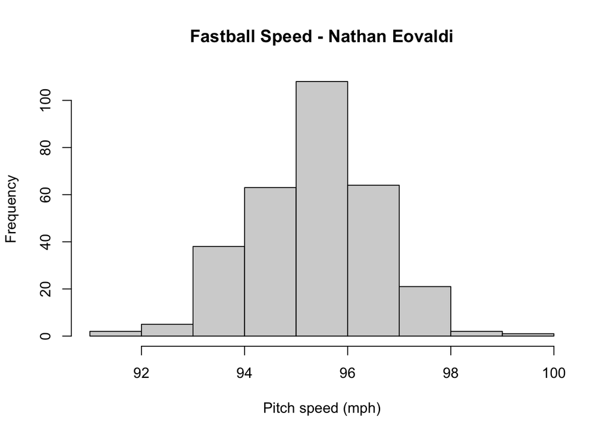

```r
with( eovaldi[ eovaldi$pitch_type=="FF",  ] , hist(release_speed, main = "Fastball Speed - Nathan Eovaldi", xlab = "Pitch speed (mph)",) )
```

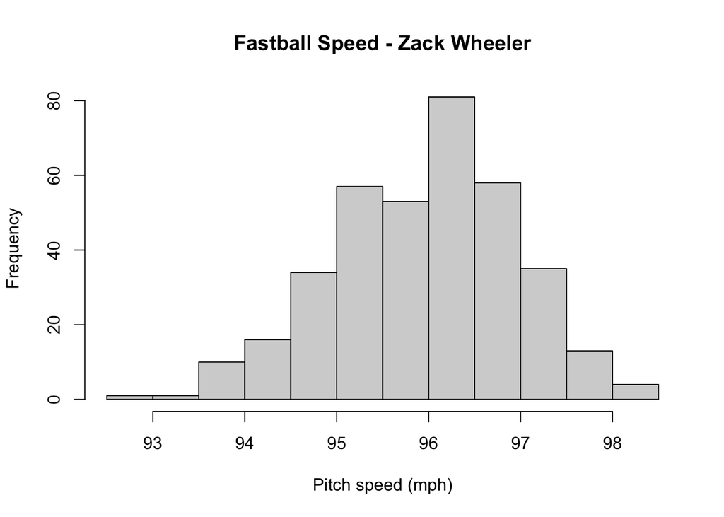

```r
with( wheeler[ wheeler$pitch_type=="FF",  ] , hist(release_speed, main = "Fastball Speed - Zack Wheeler", xlab = "Pitch speed (mph)") )
```

The histograms of the pitch speeds for the fastballs thrown by Nathan Eovaldi and Zack Wheeler are shown above. One observation that I noticed is that Nathan Eovaldi has more outliers on his fastball pitch speed on both ends (fastballs thrown that were significantly faster or slower than the average speed) while Zach Weeler’s fastball speed was more consistent.

* Calculate the strengths and weaknesses of the players by the different pitch types.

Nathan Eovaldi

```r
# Set team to analyze
team <- "TEX"

# Extract unique pitch types
pitch_types <- unique(statcast_2$pitch_name)

# Create empty vectors to store results
hit <- strike <- out <- number <- average <- wp_change <- rep(NA, length(pitch_types))

# Loop through and calculate return for each pitch type
for(i in 1:length(pitch_types)){

  # Extract data for pitch type
  temp <- statcast_2[statcast_2$pitch_name == pitch_types[i] &
                      statcast_2$pitcher_team == team,]

  # Calculate number of pitches thrown
  number[i] <- nrow(temp)
  # Calculate positive hits
  hit[i] <- sum(temp$outcome == 1, na.rm =TRUE)
  # Calculate strikes
  strike[i] <- sum(temp$outcome == 0, na.rm = TRUE)
  # Calculate outs
  out[i] <- sum(temp$outcome == -1, na.rm = TRUE)
  # Calculate average
  average[i] <- mean(temp$outcome)
  # Calculate win probability change
  wp_change[i] <- mean(temp$win_prob_change, na.rm = TRUE)

}

# Join results together
res_table_1_pitch <- cbind.data.frame(pitch_types, number, hit, strike, out, average, wp_change)
```

```r
# Extract unique pitch types
pitch_types <- unique(statcast_2$pitch_name)

# Set pitcher
pitcher <- "Eovaldi, Nathan"

# Create empty vectors to store results
hit <- strike <- out <- number <- average <- wp_change <- rep(NA, length(pitch_types))

# Loop through and calculate return for each pitch type
for(i in 1:length(pitch_types)){

  # Extract data for pitch type
  temp <- statcast_2[statcast_2$pitch_name == pitch_types[i] &
                      statcast_2$pitcher_name == pitcher,]

  # Calculate number of pitches thrown
  number[i] <- nrow(temp)
  # Calculate positive hits
  hit[i] <- sum(temp$outcome == 1, na.rm =TRUE)
  # Calculate strikes
  strike[i] <- sum(temp$outcome == 0, na.rm = TRUE)
  # Calculate outs
  out[i] <- sum(temp$outcome == -1, na.rm = TRUE)
  # Calculate average
  average[i] <- mean(temp$outcome)
  # Calculate win probability change
  wp_change[i] <- mean(temp$win_prob_change, na.rm = TRUE)
}

# Join results together
eovaldi_table <- cbind.data.frame(pitch_types, number, hit, strike, out, average, wp_change)
res_table_1_pitch[order(res_table_1_pitch$wp_change, decreasing = FALSE),]
```

|  | pitch_types | number | hit | strike | out | average | wp_change |
| --- | --- | --- | --- | --- | --- | --- | --- |
| 7 | Sweeper | 110 | 9 | 51 | 50 | -0.3727273 | -0.0069545455 |
| 8 | Knuckle Curve | 3 | 0 | 2 | 1 | -0.3333333 | -0.0056666667 |
| 9 | Split-Finger | 241 | 28 | 107 | 106 | -0.3236515 | -0.0025601660 |
| 5 | Curveball | 321 | 25 | 200 | 96 | -0.2211838 | -0.0019719626 |
| 1 | Slider | 1240 | 160 | 581 | 499 | -0.2733871 | -0.0017153226 |
| 2 | Changeup | 792 | 147 | 343 | 302 | -0.1957071 | -0.0002702020 |
| 12 | Other | 5 | 1 | 1 | 3 | -0.4000000 | 0.0000000000 |
| 6 | Cutter | 537 | 89 | 288 | 160 | -0.1322160 | 0.0009962756 |
| 4 | Sinker | 774 | 163 | 335 | 276 | -0.1459948 | 0.0012855297 |
| 3 | 4-Seam Fastball | 2004 | 348 | 942 | 714 | -0.1826347 | 0.0013418164 |

[output cut: 6 more lines]

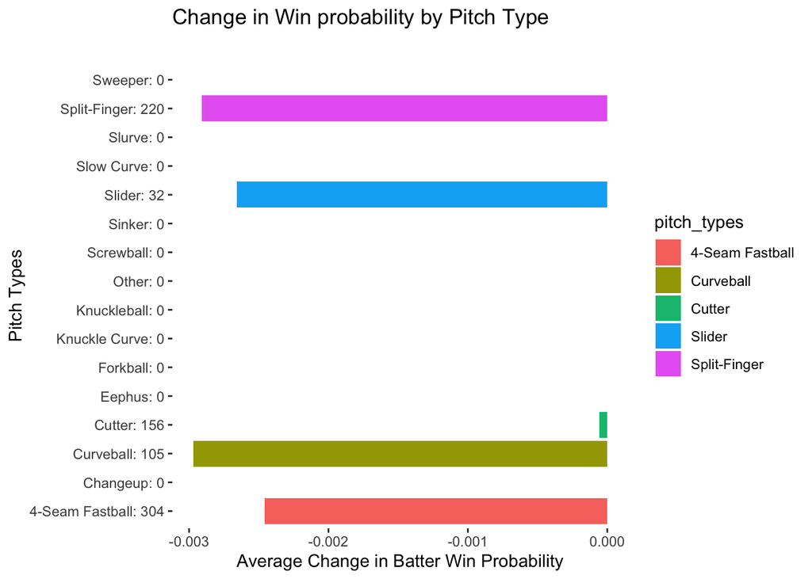

```r
# Create column with pitch type and number faced
eovaldi_table$pitch_num <- paste(eovaldi_table$pitch_types, ": ",
                                      eovaldi_table$number, sep = "")


# Create plot
g_8 <- ggplot(data = eovaldi_table, # Set dataset
              aes(x = pitch_num,  # Set x axis as pitch type
                  y= wp_change, # Set y as win probability change
                  fill = pitch_types)) + # Set fill as pitch type
  geom_bar(stat = "identity") + # Set geom bar for bar plot
  theme_bw() + # Set theme
  coord_flip() + # Flip coordinates
  labs(x = "Pitch Types", # Set labels
       y = "Average Change in Batter Win Probability",
       title = "Change in Win probability by Pitch Type",
       subtitle = "") +
  theme(panel.grid.major = element_blank(), # Remove grid
        panel.grid.minor = element_blank(), # Remove grid
        panel.border = element_blank(), # Remove grid
        panel.background = element_blank()) + # Remove grid
  guides(fill = NULL) # Turn off legend for fill

# Generate plot
g_8
```

Nathan Eovaldi’s strongest pitches are the split-finger, slider, curveball, and 4-seam fastball. His cutter appears to be a weaker pitch for him as he threw it the third most of his pitches but it only had a slight impact on the average change in batter win probability as opposed to the others that appeared to be much more effective.

Zack Wheeler

```r
# Set team to analyze
team <- "PHI"

# Extract unique pitch types
pitch_types <- unique(statcast_2$pitch_name)

# Create empty vectors to store results
hit <- strike <- out <- number <- average <- wp_change <- rep(NA, length(pitch_types))

# Loop through and calculate return for each pitch type
for(i in 1:length(pitch_types)){

  # Extract data for pitch type
  temp <- statcast_2[statcast_2$pitch_name == pitch_types[i] &
                      statcast_2$pitcher_team == team,]

  # Calculate number of pitches thrown
  number[i] <- nrow(temp)
  # Calculate positive hits
  hit[i] <- sum(temp$outcome == 1, na.rm =TRUE)
  # Calculate strikes
  strike[i] <- sum(temp$outcome == 0, na.rm = TRUE)
  # Calculate outs
  out[i] <- sum(temp$outcome == -1, na.rm = TRUE)
  # Calculate average
  average[i] <- mean(temp$outcome)
  # Calculate win probability change
  wp_change[i] <- mean(temp$win_prob_change, na.rm = TRUE)

}

# Join results together
res_table_2_pitch <- cbind.data.frame(pitch_types, number, hit, strike, out, average, wp_change)
```

```r
# Set pitcher player name
pitcher <- "Wheeler, Zack"


# Create empty vectors to store results
hit <- strike <- out <- number <- average <- wp_change <- rep(NA, length(pitch_types))

# Loop through and calculate return for each pitch type
for(i in 1:length(pitch_types)){

  # Extract data for pitch type
  temp <- statcast_2[statcast_2$pitch_name == pitch_types[i] &
                      statcast_2$pitcher_name == pitcher,]

  # Calculate number of pitches thrown
  number[i] <- nrow(temp)
  # Calculate positive hits
  hit[i] <- sum(temp$outcome == 1, na.rm =TRUE)
  # Calculate strikes
  strike[i] <- sum(temp$outcome == 0, na.rm = TRUE)
  # Calculate outs
  out[i] <- sum(temp$outcome == -1, na.rm = TRUE)
  # Calculate average
  average[i] <- mean(temp$outcome)
  # Calculate win probability change
  wp_change[i] <- mean(temp$win_prob_change, na.rm = TRUE)
}

# Join results together
res_table_player_2 <- cbind.data.frame(pitch_types, number, hit, strike, out, average, wp_change)
```

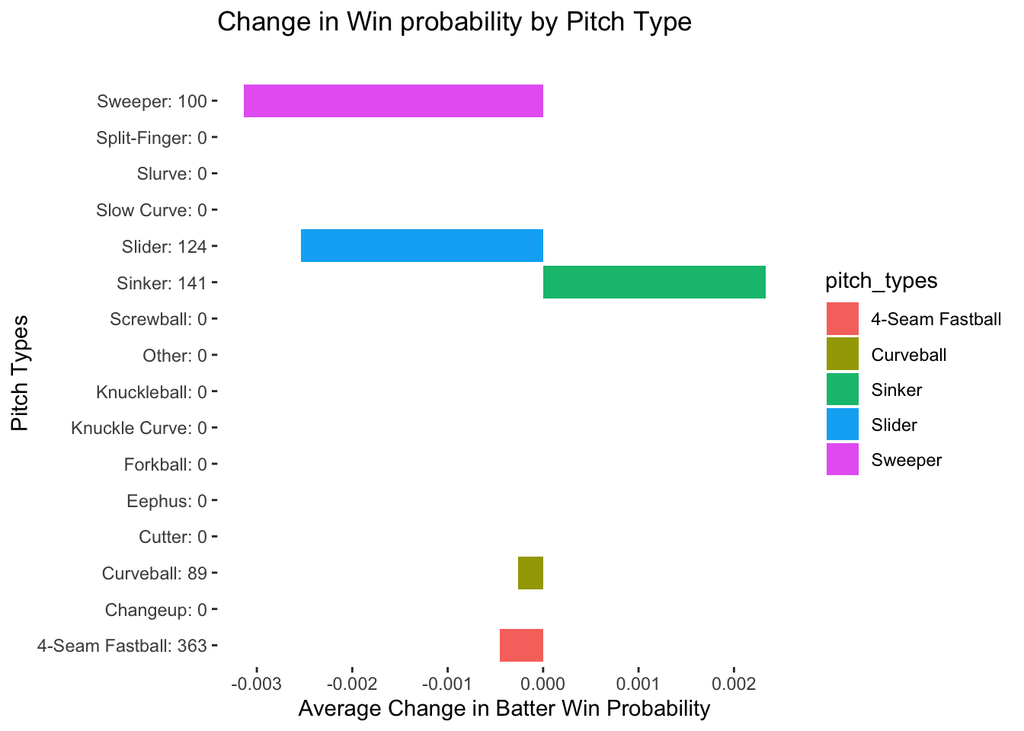

```r
# Create column with pitch type and number faced
res_table_player_2$pitch_num <- paste(res_table_player_2$pitch_types, ": ",
                                      res_table_player_2$number, sep = "")


# Create plot
g_8 <- ggplot(data = res_table_player_2, # Set dataset
              aes(x = pitch_num,  # Set x axis as pitch type
                  y= wp_change, # Set y as win probability change
                  fill = pitch_types)) + # Set fill as pitch type
  geom_bar(stat = "identity") + # Set geom bar for bar plot
  theme_bw() + # Set theme
  coord_flip() + # Flip coordinates
  labs(x = "Pitch Types", # Set labels
       y = "Average Change in Batter Win Probability",
       title = "Change in Win probability by Pitch Type",
       subtitle = "") +
  theme(panel.grid.major = element_blank(), # Remove grid
        panel.grid.minor = element_blank(), # Remove grid
        panel.border = element_blank(), # Remove grid
        panel.background = element_blank()) + # Remove grid
  guides(fill = NULL) # Turn off legend for fill

# Generate plot
g_8
```

* Analyze the match up between at least one pitcher and batter. Describe what would be some good pitches to target in the match up for the pitcher and pitches to be cautious for the batter.

```r
name <- "Harper, Bryce"

# Create empty vectors to store results
hit <- strike <- out <- number <- average <- wp_change <- rep(NA, length(pitch_types))

# Loop through and calculate return for each pitch type
for(i in 1:length(pitch_types)){

  # Extract data for pitch type and team
  temp <- statcast_2[statcast_2$pitch_name == pitch_types[i] &
                      statcast_2$player_name == name,]

  # Calculate number of pitches thrown
  number[i] <- nrow(temp)
  # Calculate positive hits
  hit[i] <- sum(temp$outcome == 1, na.rm =TRUE)
  # Calculate strikes
  strike[i] <- sum(temp$outcome == 0, na.rm = TRUE)
  # Calculate outs
  out[i] <- sum(temp$outcome == -1, na.rm = TRUE)
  # Calculate average
  average[i] <- mean(temp$outcome)
  # Calculate win probability change
  wp_change[i] <- mean(temp$win_prob_change, na.rm = TRUE)

}

# Join results together
res_table_3 <- cbind.data.frame(pitch_types, number, hit, strike, out, average, wp_change)
```

```r
res_table_3[order(res_table_3$wp_change, decreasing = TRUE),]
```

|  | pitch_types | number | hit | strike | out | average | wp_change |
| --- | --- | --- | --- | --- | --- | --- | --- |
| 14 | Forkball | 3 | 2 | 1 | 0 | 0.66666667 | 0.0360000000 |
| 7 | Sweeper | 17 | 2 | 9 | 6 | -0.23529412 | 0.0140588235 |
| 5 | Curveball | 34 | 9 | 13 | 12 | -0.08823529 | 0.0077941176 |
| 6 | Cutter | 29 | 9 | 9 | 11 | -0.06896552 | 0.0051379310 |
| 4 | Sinker | 48 | 13 | 19 | 16 | -0.06250000 | 0.0034583333 |
| 3 | 4-Seam Fastball | 108 | 27 | 50 | 31 | -0.03703704 | 0.0007592593 |
| 2 | Changeup | 62 | 12 | 32 | 18 | -0.09677419 | 0.0002741935 |
| 12 | Other | 1 | 1 | 0 | 0 | 1.00000000 | 0.0000000000 |
| 13 | Slurve | 4 | 0 | 3 | 1 | -0.25000000 | -0.0025000000 |
| 1 | Slider | 87 | 12 | 40 | 35 | -0.26436782 | -0.0038505747 |

[output cut: 6 more lines]

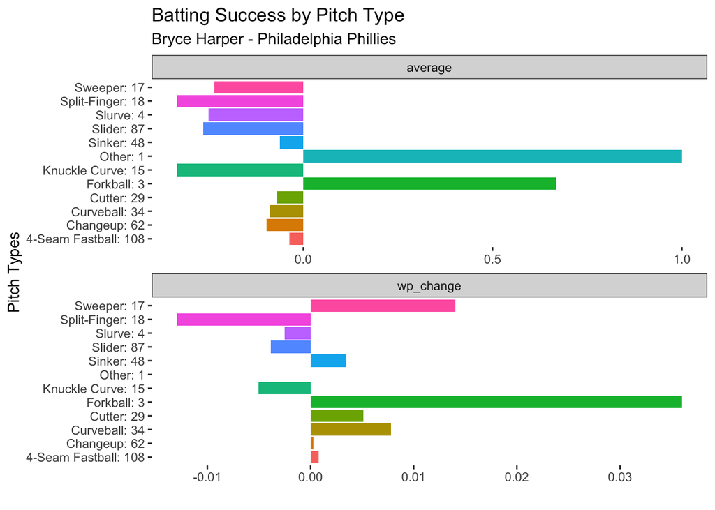

```r
# Create column with pitch type and number faced (so can ba axis on graph)
res_table_3$pitch_num <- paste(res_table_3$pitch_types, ": ", res_table_3$number, sep = "")
# Melt data and drop 0 values
plot_db <- melt(res_table_3[res_table_3$number != 0, c("pitch_num", "average", "wp_change")])
# Create plot
g_1 <- ggplot(data = plot_db, # Set dataset
              aes(x = pitch_num,  # Set x axis as pitch type
                  y= value, # Set y as return
                  fill = pitch_num)) + # Set fill as pitch type
  geom_bar(stat = "identity") + # Set geom bar for bar plot
  facet_wrap(~ variable, scales = "free", nrow = 2) +
  theme_bw() + # Set theme
  coord_flip() + # Flip coordinates
  labs(x = "Pitch Types", # Set labels
       y = "",
       title = "Batting Success by Pitch Type",
       subtitle = "Bryce Harper - Philadelphia Phillies") +
  theme(panel.grid.major = element_blank(), # Remove grid
        panel.grid.minor = element_blank(), # Remove grid
        panel.border = element_blank(), # Remove grid
        panel.background = element_blank(), # Remove grid
        legend.position="none") + # Turn off legend
  guides(fill = NULL) # Turn off legend for fill

# Generate plot
g_1
```

```r
# Set pitcher to analyze
name <- "Eovaldi, Nathan"

# Create empty vectors to store results
hit <- strike <- out <- number <- average <- wp_change <- rep(NA, length(pitch_types))

# Loop through and calculate return for each pitch type
for(i in 1:length(pitch_types)){

  # Extract data for pitch type
  temp <- statcast_2[statcast_2$pitch_name == pitch_types[i] &
                      statcast_2$pitcher_name == name,]

  # Calculate number of pitches thrown
  number[i] <- nrow(temp)
  # Calculate positive hits
  hit[i] <- sum(temp$outcome == 1, na.rm =TRUE)
  # Calculate strikes
  strike[i] <- sum(temp$outcome == 0, na.rm = TRUE)
  # Calculate outs
  out[i] <- sum(temp$outcome == -1, na.rm = TRUE)
  # Calculate average
  average[i] <- mean(temp$outcome)
  # Calculate win probability change
  wp_change[i] <- mean(temp$win_prob_change, na.rm = TRUE)

}

# Join results together
res_table_3_pitch <- cbind.data.frame(pitch_types, number, hit, strike, out, average, wp_change)
```

```r
res_table_3_pitch[order(res_table_3_pitch$wp_change, decreasing = FALSE),]
```

|  | pitch_types | number | hit | strike | out | average | wp_change |
| --- | --- | --- | --- | --- | --- | --- | --- |
| 5 | Curveball | 105 | 8 | 63 | 34 | -0.2476190 | -2.971429e-03 |
| 9 | Split-Finger | 220 | 27 | 96 | 97 | -0.3181818 | -2.909091e-03 |
| 1 | Slider | 32 | 7 | 9 | 16 | -0.2812500 | -2.656250e-03 |
| 3 | 4-Seam Fastball | 304 | 51 | 129 | 124 | -0.2401316 | -2.457237e-03 |
| 6 | Cutter | 156 | 27 | 80 | 49 | -0.1410256 | -5.769231e-05 |
| 2 | Changeup | 0 | 0 | 0 | 0 | NaN | NaN |
| 4 | Sinker | 0 | 0 | 0 | 0 | NaN | NaN |
| 7 | Sweeper | 0 | 0 | 0 | 0 | NaN | NaN |
| 8 | Knuckle Curve | 0 | 0 | 0 | 0 | NaN | NaN |
| 10 | Slow Curve | 0 | 0 | 0 | 0 | NaN | NaN |

[output cut: 6 more lines]

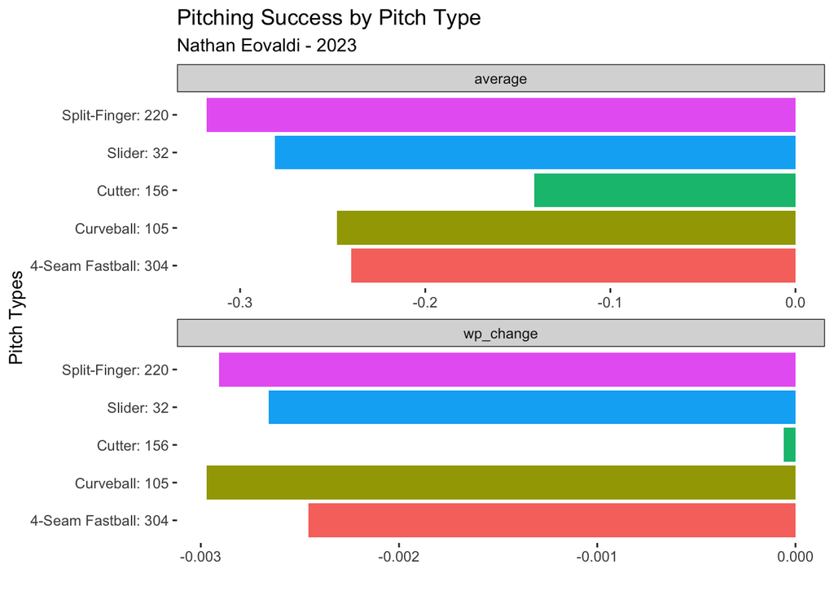

```r
# Create column with pitch type and number faced
res_table_3_pitch$pitch_num <- paste(res_table_3_pitch$pitch_types, ": ", res_table_3_pitch$number, sep = "")
# Melt data and drop 0 values
plot_db_3p <- melt(res_table_3_pitch[res_table_3_pitch$number != 0, c("pitch_num", "average", "wp_change")])
# Create plot
g_7 <- ggplot(data = plot_db_3p, # Set dataset
              aes(x = pitch_num,  # Set x axis as pitch type
                  y= value, # Set y as return
                  fill = pitch_num)) + # Set fill as pitch type
  geom_bar(stat = "identity") + # Set geom bar for bar plot
  facet_wrap(~ variable, scales = "free", nrow = 2) +
  theme_bw() + # Set theme
  coord_flip() + # Flip coordinates
  labs(x = "Pitch Types", # Set labels
       y = "",
       title = "Pitching Success by Pitch Type",
       subtitle = "Nathan Eovaldi - 2023") +
  theme(panel.grid.major = element_blank(), # Remove grid
        panel.grid.minor = element_blank(), # Remove grid
        panel.border = element_blank(), # Remove grid
        panel.background = element_blank(), # Remove grid
        legend.position="none") + # Turn off legend
  guides(fill = NULL) # Turn off legend for fill

# Generate plot
g_7
```

```r
#phillies batters against rangers pitchers (harper against eovaldi here)
team_2_bat_prob <- cbind.data.frame(res_table_3$pitch_types,
                                    (res_table_3$wp_change + res_table_3_pitch$wp_change)/2)
names(team_2_bat_prob) <- c("pitch_types", "exp_wp")
```

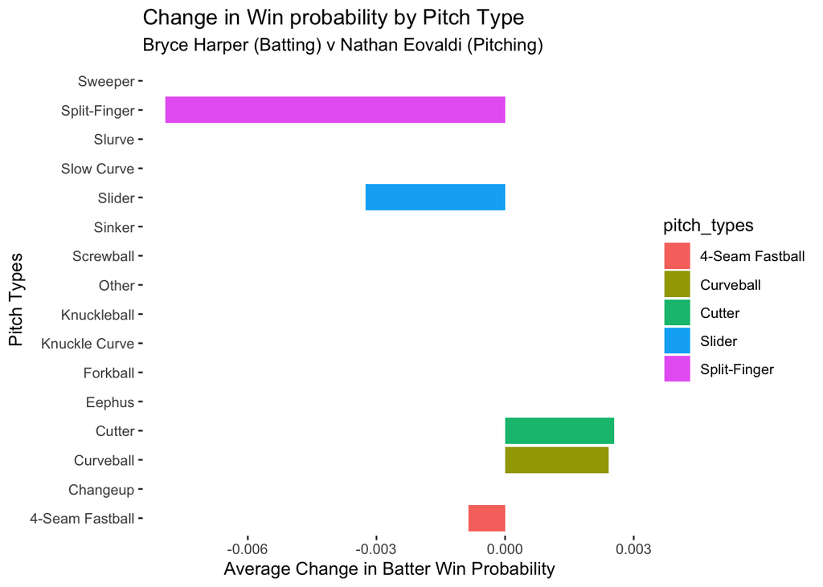

```r
# Create plot
g_10 <- ggplot(data = team_2_bat_prob, # Set dataset
              aes(x = pitch_types,  # Set x axis as pitch type
                  y= exp_wp, # Set y as win probability change
                  fill = pitch_types)) + # Set fill as pitch type
  geom_bar(stat = "identity") + # Set geom bar for bar plot
  theme_bw() + # Set theme
  coord_flip() + # Flip coordinates
  labs(x = "Pitch Types", # Set labels
       y = "Average Change in Batter Win Probability",
       title = "Change in Win probability by Pitch Type",
       subtitle = "Bryce Harper (Batting) v Nathan Eovaldi (Pitching)") +
  theme(panel.grid.major = element_blank(), # Remove grid
        panel.grid.minor = element_blank(), # Remove grid
        panel.border = element_blank(), # Remove grid
        panel.background = element_blank()) + # Remove grid
  guides(fill = NULL) # Turn off legend for fill

# Generate plot
g_10
```